### Variable contribution

It’s possible to change the color and the shape of the variable points as well as the number of top variables, i.e. the ones having the highest contribution.

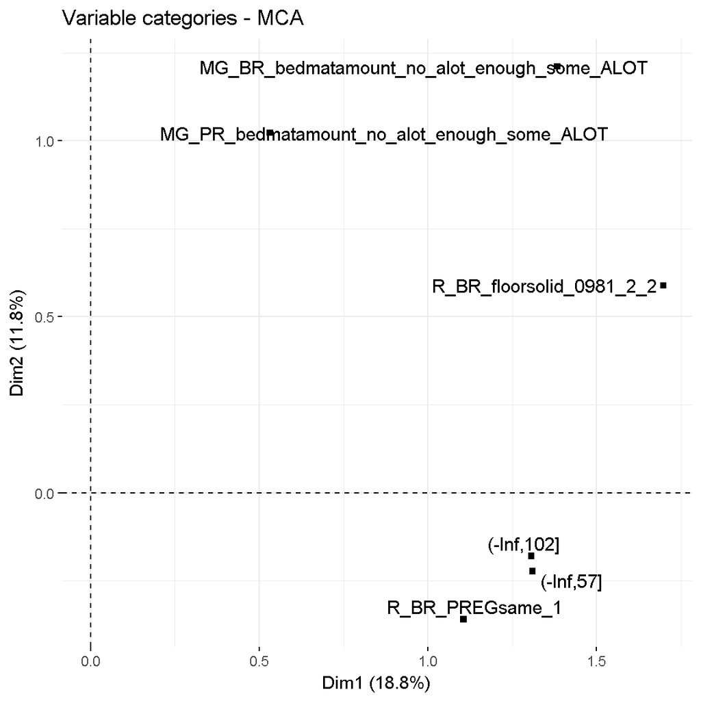

```r
fviz_mca_var(res_mca, col.var="black", shape.var = 15,
             repel = TRUE,select.var = list(contrib = 6))
```

It is also possible to control the transparency of variable categories according to their contribution values.

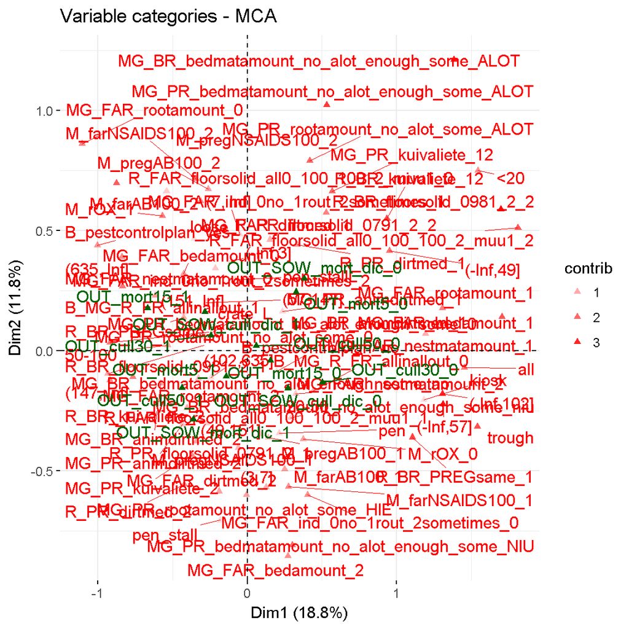

```r
# Change the transparency by contrib values
fviz_mca_var(res_mca, alpha.var="contrib",
             repel = TRUE,
             ggtheme = theme_minimal())
```

The most contributing, i.e. important variable categories can be visualized by gradient-colouring them respect to their contribution value. Meaning basically, that low, medium and high contributions have different colours.

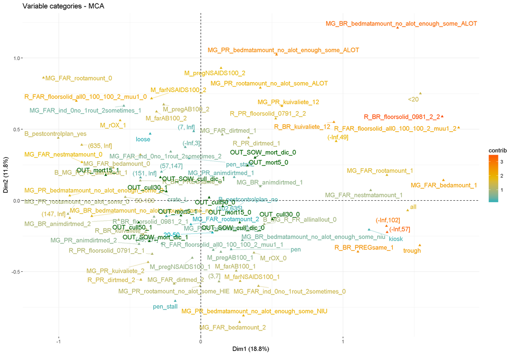

```r
fviz_mca_var(res_mca, col.var = "contrib",
             gradient.cols = c("#00AFBB", "#E7B800", "#FC4E07"),
             repel = TRUE, # avoid text overlapping (slow)
             ggtheme = theme_minimal()
             )
```

Simple bar plots can also be used to visualize contribution of variable categories. The top 12 variable categories contributing to the first and second dimension:

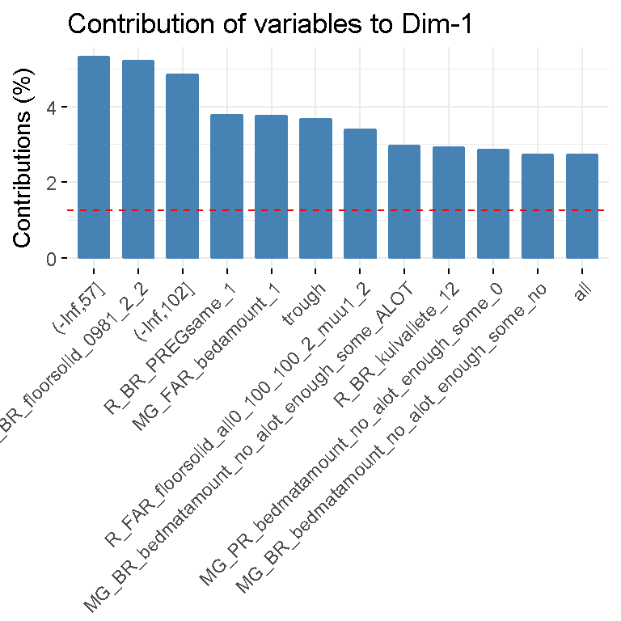

```r
# Contributions of rows to dimension 1
fviz_contrib(res_mca, choice = "var", axes = 1, top = 12)
```

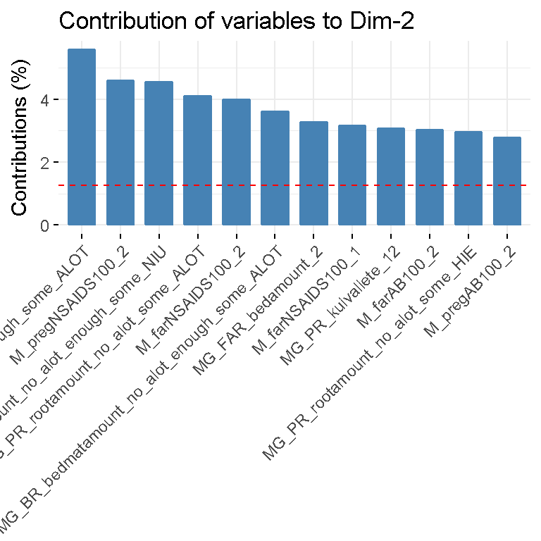

```r
# Contributions of rows to dimension 2
fviz_contrib(res_mca, choice = "var", axes = 2, top = 12)
```

The red dashed line indicates the expected average value, If the contributions were uniform.